# PPOL670 | Interpretable Machine Learning | Week 12

## Marginal Effects

### Partial Dependencies

It’s useful to know that `age` and `wage` are important to the model, but how do they relate to whether an individual is covered or not in the data? Let’s explore a partial dependency plot to unpack the average marginal effect for `age` and `wage`.

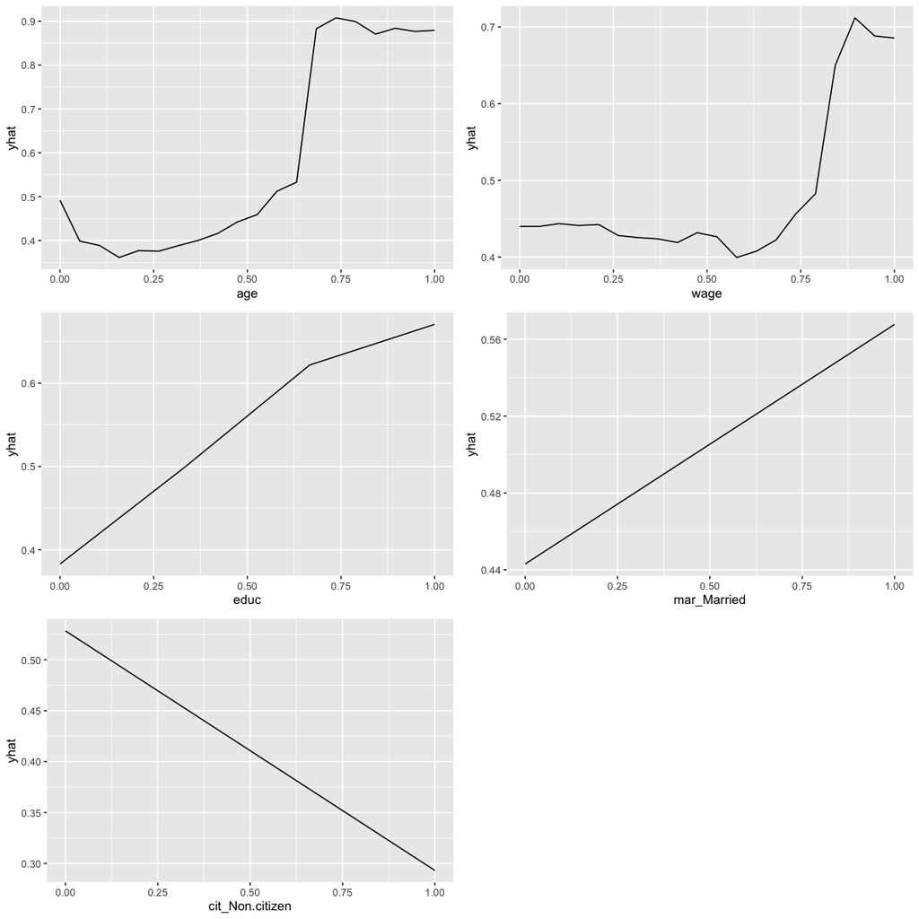

```r
# PDP for age
age_pdp <- partial(mod_rf_selected, pred.var = "age", plot = TRUE,prob=T,
                   grid.resolution = 20, # choosing less points makes it run quicker
                   plot.engine = "ggplot2")

# PDP for wage
wage_pdp <- partial(mod_rf_selected, pred.var = "wage", plot = TRUE,prob=T,
                    grid.resolution = 20, # choosing less points makes it run quicker
                   plot.engine = "ggplot2")

# PDP for education level
educ_pdp <- partial(mod_rf_selected, pred.var = "educ", plot = TRUE,prob=T,
                    grid.resolution = 4,plot.engine = "ggplot2")

# PDP for Married (note that this is a dummy var, so only can take on one of two values)
mar_pdp <- partial(mod_rf_selected, pred.var = "mar_Married", plot = TRUE,prob=T,
                   plot.engine = "ggplot2")

# PDP for Not a citizen (note that this is a dummy var, so only can take on one of two values)
cit_pdp <- partial(mod_rf_selected, pred.var = "cit_Non.citizen", plot = TRUE,prob=T,
                   plot.engine = "ggplot2")

# GridExtra allows us to stack two ggplot objects into a single plot
gridExtra::grid.arrange(age_pdp,wage_pdp,educ_pdp,mar_pdp,cit_pdp)
```

### Individual Conditional Expectations

One additional question we might want to ask is whether there is are important *interactions*. One way we can explore this is if we look at the individual expectations for each observation in the data as we manipulate the values of the target variable. If the ICE curves diverge (have different trajectories), that can be evidence that there is a potential interaction.

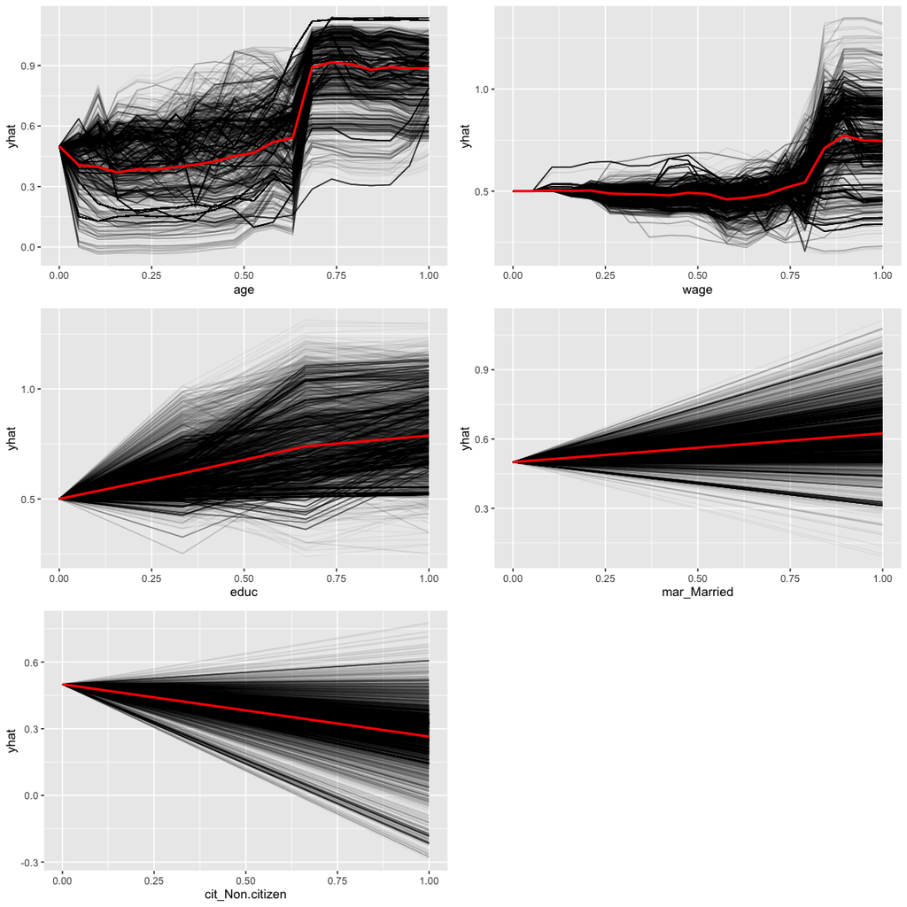

A few things to note here:

- It looks like there is a potential interaction in `wage`. Notice how some of the curves have a very different trend toward the end of the distribution? The reason for this is likely due to some interaction.
- The idea that only old people are covered (our conclusion after looking at the PDP plot) isn’t entirely accurate. In fact, there are a number of respondents in the data that are predicted to have a higher probability of coverage at a young age; however, these observations are canceled out by other young respondents who are less likely to be covered.
- Likewise it looks like there is heterogeneity in the effect of education on the likelihood of being covered.
- Finally, for the dummy variables, note how the impact of being married or not a citizen impacts different respondents differently in the model.

Let’s now explore the potential interaction between `wage` and `age`, `wage` and `educ`, and `educ` and `wage`. Is it the combination of being wealthy and old that corresponds with coverage, or does wealth make younger people more willing to purchase coverage?

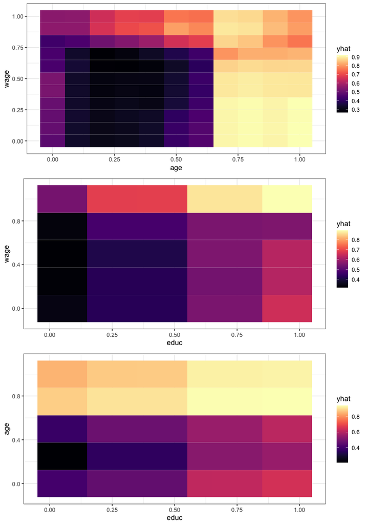

From the above plot, we can indeed see that there is an interaction between `age` and `wage`. Specifically,

- We still note the threshold effect past .65 on the age scale (that is, all older people are more likely to be covered).
- However, what this plot demonstrates is that wage mediates age. Even if you’re young, if you’re making a high salary you’re more likely to be covered. Chances are that a high wage is correlated with employer-provided health coverage.
- Finally, there appears to be a major region in which the model predicts a lower probability of coverage. Specifically for young people who don’t have a high paying wage.

W/r/t education and wage: the probability of coverage is highest for educated people who are on the high end of the wage distribution. However, the effect of education is much less (even for highly educated people) if they are lower on the wage distribution.

W/r/t education and age, it doesn’t look like there is much of an interaction.

## Global Surrogate Model

### Tree

The random forest model does a fantastic job at predicting the likelihood of coverage, but it’s difficult to interpret. In the above sections we explored variable importance and the marginal effects of dependencies of the variables on the predicted probabilities to gain some insight into how the model is using the data to make its predictions. Let’s now take this a step further by building a **global surrogate model**. The aim here is to build a more interpretable model *on top* of our black box model. That is, we can train an interpretable model to approximate the predictions of the random forest model. We can then interpret this more interpretable model.

```r
train_data3 <-
  train_data2 %>%
  mutate(
    # Probability predictions from the random forest model
    coverage_probs = predict(mod_rf_selected,type = "prob")$Coverage
  )


surrogate_tree <-

  # Decision tree model (directly us the model rather than use the implementation in caret)
  rpart::rpart(
    # Main selected model. The outcome is now the predicted probabilities from
    # the RF model
    coverage_probs ~ age + wage + educ + mar_Married + cit_Non.citizen,

    # Data is being passed by the pipe
    data = train_data3,

    # Note that we can control the depth of the tree
    # a deeper tree increase fit but reduces interpretability
    control = rpart::rpart.control(maxdepth = 4)
  )
```

Let’s now assess the model fit.

```r
tibble(truth = train_data3$coverage_probs,
       estimate = predict(surrogate_tree)) %>%
  rsq(truth,estimate)
```

| .metric | .estimator | .estimate |
| --- | --- | --- |
| rsq | standard | 0.778555 |

An R-Squared of .78 isn’t bad. It indicates that the surrogate model does a good job approximating the black box model (i.e. the random forest model).

Let’s now look at the tree.

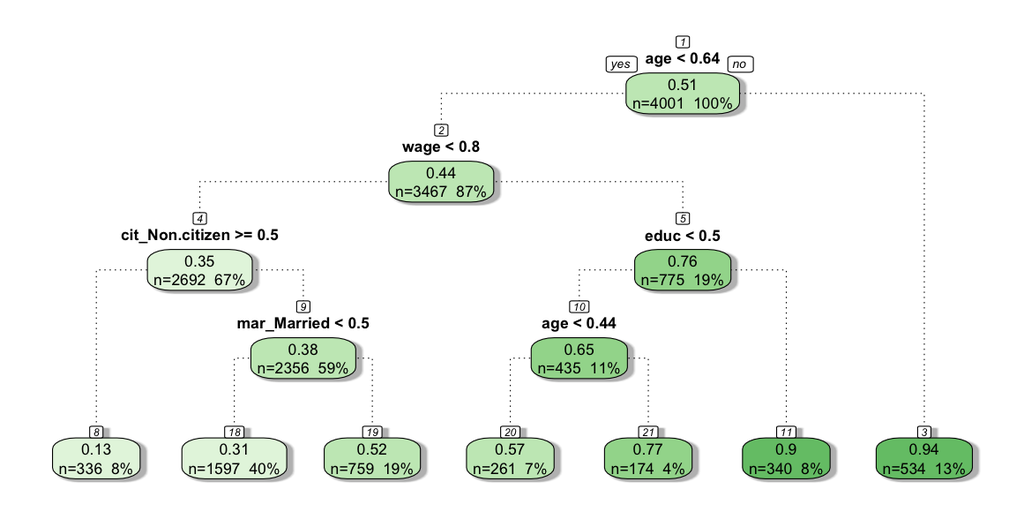

```r
rattle::fancyRpartPlot(surrogate_tree,sub="",type=1)
```

*NOTE*: that if we built a deeper model, a richer story emerges. But that story doesn’t differ much from the one we’ve already been piecing together.

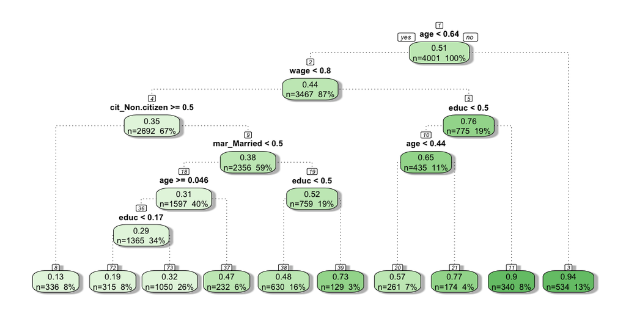

```r
surrogate_tree2 <-
  rpart::rpart(coverage_probs ~ age + wage + educ + mar_Married + cit_Non.citizen,
    data = train_data3,
    control = rpart::rpart.control(maxdepth = 7)
  )
rattle::fancyRpartPlot(surrogate_tree2,sub="",type=1)
```

### Linear Model

We can use the insights above to build out a linear model (actually, a logistic model b/c the outcome is binary) to help with interpretability.

```r
linear_surrogate_model <-
  train_data2 %>%
  mutate(coverage_dummy = 1*(coverage == "Coverage")) %>%
  glm(coverage_dummy ~
        age*wage +
        wage*educ +
        mar_Married +
        cit_Non.citizen,
      data=.,family = binomial("logit"))

# Print the regression results
stargazer::stargazer(linear_surrogate_model,type = "text")
```

[output not shown]

```
=============================================
                      Dependent variable:
                  ---------------------------
                        coverage_dummy
---------------------------------------------
age                        3.505***
                            (0.230)

wage                        0.418*
                            (0.243)

educ                       0.821***
                            (0.247)

mar_Married                0.690***
                            (0.077)

cit_Non.citizen            -1.551***
                            (0.148)

age:wage                   -1.925***
                            (0.475)

wage:educ                  2.345***
                            (0.416)

Constant                   -1.988***
                            (0.128)

---------------------------------------------
Observations                 4,001
Log Likelihood            -2,230.519
Akaike Inf. Crit.          4,477.038
=============================================
Note:             *p<0.1; **p<0.05; ***p<0.01
```

We could now test these theoretical insights on new, previously unseen data… i.e. the test data!

How well does the theoretical model predict future data? Pretty well, which indicates that our insights likely *generalize* to the test data.

```r
Metrics::auc(actual = 1*(test_data2$coverage=="Coverage"),
             predicted = predict(linear_surrogate_model,
                                 newdata = test_data2))
```

```
[1] 0.7827528
```

# Theory Development

We’ve learned a lot from the training data and model about the factors that increase the likelihood of coverage. We’ve generated a number of interesting hypotheses: